# Veri Madenciliği Final

Selin Nur Gültekin-121516031

25 01 2021

# Soru 1

**Veri Giriş Bölümü**

Verimin kaynagi: https://www.kaggle.com/andrewmvd/heart-failure-clinical-data

Ek kaynak : https://bmcmedinformdecismak.biomedcentral.com/articles/10.1186/s12911-020-1023-5#Sec2

**Verim Hakkinda bilgi:**

Veri setinde yer alan 12 özelliğe dayanarak kalp yetmezliğine bağlı ölüm oranlarını tahmin edeceğiz. Bu, hastanelerin kardiyovasküler hastalıkları olan hastaların şiddetini değerlendirmesine yardımcı olmak için kullanılabilir. Kardiyovasküler hastalıklar (KVH), dünya çapında 1 numaralı ölüm nedenidir ve her yıl tahmini 17,9 milyon kişinin hayatını almaktadır ve bu, dünya çapındaki tüm ölümlerin% 31’ini oluşturmaktadır .

[output not shown]

*Bağımlı değişkenimiz “DEATH_EVENT” dir.*

|  | age | anaemia | creatinine_phosphokinase | diabetes | ejection_fraction | high_blood_pressure | platelets | serum_creatinine | serum_sodium | sex | smoking | time | DEATH_EVENT |
| --- | --- | --- | --- | --- | --- | --- | --- | --- | --- | --- | --- | --- | --- |
| 1 | 75 | 0 | 582 | 0 | 20 | 1 | 265000 | 1.9 | 130 | 1 | 0 | 4 | 1 |
| 2 | 55 | 0 | 7861 | 0 | 38 | 0 | 263358.03 | 1.1 | 136 | 1 | 0 | 6 | 1 |
| 3 | 65 | 0 | 146 | 0 | 20 | 0 | 162000 | 1.3 | 129 | 1 | 1 | 7 | 1 |
| 4 | 50 | 1 | 111 | 0 | 20 | 0 | 210000 | 1.9 | 137 | 1 | 0 | 7 | 1 |
| 5 | 65 | 1 | 160 | 1 | 20 | 0 | 327000 | 2.7 | 116 | 0 | 0 | 8 | 1 |
| 6 | 90 | 1 | 47 | 0 | 40 | 1 | 204000 | 2.1 | 132 | 1 | 1 | 8 | 1 |
| 7 | 75 | 1 | 246 | 0 | 15 | 0 | 127000 | 1.2 | 137 | 1 | 0 | 10 | 1 |
| 8 | 60 | 1 | 315 | 1 | 60 | 0 | 454000 | 1.1 | 131 | 1 | 1 | 10 | 1 |
| 9 | 65 | 0 | 157 | 0 | 65 | 0 | 263358.03 | 1.5 | 138 | 0 | 0 | 10 | 1 |
| 10 | 80 | 1 | 123 | 0 | 35 | 1 | 388000 | 9.4 | 133 | 1 | 1 | 10 | 1 |

[output cut: 40 more lines]

Data summary

| Name | df |
| --- | --- |
| Number of rows | 299 |
| Number of columns | 13 |
| _______________________ |  |
| Column type frequency: |  |
| numeric | 13 |
| ________________________ |  |
| Group variables | None |

**Variable type: numeric**

| skim_variable | n_missing | complete_rate | mean | sd | p0 | p25 | p50 | p75 | p100 | hist |
| --- | --- | --- | --- | --- | --- | --- | --- | --- | --- | --- |
| age | 0 | 1 | 60.83 | 11.89 | 40.0 | 51.0 | 60.0 | 70.0 | 95.0 | ▆▇▇▂▁ |
| anaemia | 0 | 1 | 0.43 | 0.50 | 0.0 | 0.0 | 0.0 | 1.0 | 1.0 | ▇▁▁▁▆ |
| creatinine_phosphokinase | 0 | 1 | 581.84 | 970.29 | 23.0 | 116.5 | 250.0 | 582.0 | 7861.0 | ▇▁▁▁▁ |
| diabetes | 0 | 1 | 0.42 | 0.49 | 0.0 | 0.0 | 0.0 | 1.0 | 1.0 | ▇▁▁▁▆ |
| ejection_fraction | 0 | 1 | 38.08 | 11.83 | 14.0 | 30.0 | 38.0 | 45.0 | 80.0 | ▃▇▂▂▁ |
| high_blood_pressure | 0 | 1 | 0.35 | 0.48 | 0.0 | 0.0 | 0.0 | 1.0 | 1.0 | ▇▁▁▁▅ |
| platelets | 0 | 1 | 263358.03 | 97804.24 | 25100.0 | 212500.0 | 262000.0 | 303500.0 | 850000.0 | ▂▇▂▁▁ |
| serum_creatinine | 0 | 1 | 1.39 | 1.03 | 0.5 | 0.9 | 1.1 | 1.4 | 9.4 | ▇▁▁▁▁ |
| serum_sodium | 0 | 1 | 136.63 | 4.41 | 113.0 | 134.0 | 137.0 | 140.0 | 148.0 | ▁▁▃▇▁ |
| sex | 0 | 1 | 0.65 | 0.48 | 0.0 | 0.0 | 1.0 | 1.0 | 1.0 | ▅▁▁▁▇ |
| smoking | 0 | 1 | 0.32 | 0.47 | 0.0 | 0.0 | 0.0 | 1.0 | 1.0 | ▇▁▁▁▃ |
| time | 0 | 1 | 130.26 | 77.61 | 4.0 | 73.0 | 115.0 | 203.0 | 285.0 | ▆▇▃▆▃ |
| DEATH_EVENT | 0 | 1 | 0.32 | 0.47 | 0.0 | 0.0 | 0.0 | 1.0 | 1.0 | ▇▁▁▁▃ |

Veri setimizde eksik gözlem yoktu ve gerekli düzenlemeler yapılmıştır.

**Veri ön işleme**

`İnitial_split ()` işlevi, tren setini ve test setini bölmek için kullanılır. Veri kümesini, hedef değişkenin oranını korurken, “DEATH_EVENT” öğesini “strata” bağımsız değişkeni olarak belirterek bölebilirsiniz. Tüm çekirdek değerleri 0’da sabitlenmiştir.

```r
set.seed(0)
df_split <- initial_split(df, p = 0.8, strata = DEATH_EVENT)
train <- training(df_split)
test <- testing(df_split)
head(train)
```

```
##   age anaemia creatinine_phosphokinase diabetes ejection_fraction
## 1  75       0                      582        0                20
## 3  65       0                      146        0                20
## 4  50       1                      111        0                20
## 5  65       1                      160        1                20
## 7  75       1                      246        0                15
## 8  60       1                      315        1                60
##   high_blood_pressure platelets serum_creatinine serum_sodium sex smoking time
## 1                   1    265000              1.9          130   1       0    4
## 3                   0    162000              1.3          129   1       1    7
## 4                   0    210000              1.9          137   1       0    7
## 5                   0    327000              2.7          116   0       0    8
## 7                   0    127000              1.2          137   1       0   10
## 8                   0    454000              1.1          131   1       1   10
##   DEATH_EVENT
## 1           1
## 3           1
## 4           1
## 5           1
## 7           1
## 8           1
```

```r
set.seed(0)
df_n_split <- initial_split(df_n, p = 0.8, strata = DEATH_EVENT)
train_n <- training(df_n_split)
test_n <- testing(df_n_split)
head(train_n)
```

```
##   age anaemia creatinine_phosphokinase diabetes ejection_fraction
## 1  75       0                      582        0                20
## 3  65       0                      146        0                20
## 4  50       1                      111        0                20
## 5  65       1                      160        1                20
## 7  75       1                      246        0                15
## 8  60       1                      315        1                60
##   high_blood_pressure platelets serum_creatinine serum_sodium sex smoking time
## 1                   1    265000              1.9          130   1       0    4
## 3                   0    162000              1.3          129   1       1    7
## 4                   0    210000              1.9          137   1       0    7
## 5                   0    327000              2.7          116   0       0    8
## 7                   0    127000              1.2          137   1       0   10
## 8                   0    454000              1.1          131   1       1   10
##   DEATH_EVENT
## 1           1
## 3           1
## 4           1
## 5           1
## 7           1
## 8           1
```

## Lojistik regresyon analizi

Lojistik regresyon analizi, bir olayın meydana gelme olasılığını tahmin etmek ve analiz etmek için kullanılan bir modeldir (bu durumda, ’DEATH_EVENT == 1`) Maksimum olabilirlik yöntemini kullanarak parametreleri (kesişme ve regresyon katsayıları) tahmin ederek, oranlardaki değişikliği hesaplamak mümkündür (olayın gerçekleşme olasılığının olayın gerçekleşmeme olasılığına oranı) açıklayıcı değişkenlerin değerleri değiştiğinde.

Lojistik regresyon analizinde, belirleme katsayısı (artıkların karelerinin toplamına dayanan) bir değerlendirme kriteri olarak kullanılamaz.Çünkü parametreler, en küçük kareler yöntemi (artıkların karelerinin toplamını en aza indiren) yerine maksimum olabilirlik yöntemi kullanılarak tahmin edilmektedir. Bu nedenle, McFadden’ın olasılığa dayalı sözde belirleme katsayısını hesaplıyoruz.

```r
lr1 <- glm(DEATH_EVENT ~ .,
           family=binomial(logit), data=train)
tab_model(lr1, show.r2 = FALSE, transform = NULL,
          digits = 3, digits.p = 4)
```

|  | DEATH EVENT |  |  |
| --- | --- | --- | --- |
| Predictors | Log-Odds | CI | p |
| (Intercept) | 13.664 | 0.960 – 27.492 | **0.0420** |
| age | 0.054 | 0.020 – 0.092 | **0.0027** |
| anaemia [1] | 0.151 | -0.628 – 0.927 | 0.7024 |
| creatinine_phosphokinase | 0.000 | -0.000 – 0.001 | 0.3704 |
| diabetes [1] | 0.033 | -0.734 – 0.795 | 0.9329 |
| ejection_fraction | -0.074 | -0.111 – -0.040 | **<0.001** |
| high_blood_pressure [1] | -0.106 | -0.916 – 0.685 | 0.7943 |
| platelets | -0.000 | -0.000 – 0.000 | 0.2865 |
| serum_creatinine | 0.648 | 0.297 – 1.053 | **0.0005** |
| serum_sodium | -0.095 | -0.192 – -0.004 | **0.0470** |
| sex [1] | -0.712 | -1.651 – 0.191 | 0.1274 |
| smoking [1] | 0.204 | -0.702 – 1.120 | 0.6585 |
| time | -0.020 | -0.027 – -0.014 | **<0.001** |
| Observations | 240 |  |  |

```r
PseudoR2(lr1)
```

```
## McFadden
## 0.416465
```

Burada “p”, anlamlılık olasılığını temsil eder. Parametrenin “p” değeri ne kadar düşükse, o kadar anlamlıdır ve değer 0,05’ten büyükse, anlamlı olarak değerlendirilmez. Bu modelde istatistiksel olarak anlamlı olmayan birçok değişken olduğunu görebiliriz. Bu nedenle, değişken seçimi için aşamalı yöntemi kullanacağız.

Aşamalı yöntemde, açıklayıcı değişkenlerin seçimi değiştirilirken model birçok kez yeniden oluşturulur. Daha küçük AIC (Akaike Information Criterion; modelin basitliği ile modelin uyum iyiliği arasındaki dengenin bir ölçüsü) değerine sahip model daha iyi model olarak bırakılmıştır.

```r
lr2 <- step(lr1)
```

```
## Start:  AIC=201.76
## DEATH_EVENT ~ age + anaemia + creatinine_phosphokinase + diabetes +
##     ejection_fraction + high_blood_pressure + platelets + serum_creatinine +
##     serum_sodium + sex + smoking + time
##
##                            Df Deviance    AIC
## - diabetes                  1   175.77 199.77
## - high_blood_pressure       1   175.83 199.83
## - anaemia                   1   175.91 199.91
## - smoking                   1   175.96 199.96
## - creatinine_phosphokinase  1   176.57 200.57
## - platelets                 1   176.90 200.90
## <none>                          175.76 201.76
## - sex                       1   178.14 202.14
## - serum_sodium              1   179.94 203.94
## - age                       1   185.85 209.85
## - serum_creatinine          1   188.97 212.97
## - ejection_fraction         1   196.12 220.12
## - time                      1   229.34 253.34
##
## Step:  AIC=199.77
## DEATH_EVENT ~ age + anaemia + creatinine_phosphokinase + ejection_fraction +
##     high_blood_pressure + platelets + serum_creatinine + serum_sodium +
##     sex + smoking + time
##
##                            Df Deviance    AIC
## - high_blood_pressure       1   175.83 197.83
## - anaemia                   1   175.91 197.91
## - smoking                   1   175.96 197.96
## - creatinine_phosphokinase  1   176.59 198.59
## - platelets                 1   176.90 198.90
## <none>                          175.77 199.77
## - sex                       1   178.15 200.15
## - serum_sodium              1   180.02 202.02
## - age                       1   185.86 207.86
## - serum_creatinine          1   188.98 210.98
## - ejection_fraction         1   196.13 218.13
## - time                      1   229.43 251.43
##
## Step:  AIC=197.83
```

[output cut: 72 more lines]

```
## - serum_creatinine   1   191.78 203.78
## - ejection_fraction  1   198.87 210.87
## - time               1   233.56 245.56
##
## Step:  AIC=191.48
## DEATH_EVENT ~ age + ejection_fraction + serum_creatinine + serum_sodium +
##     time
##
##                     Df Deviance    AIC
## <none>                   179.48 191.48
## - serum_sodium       1   183.61 193.61
## - age                1   187.83 197.83
## - serum_creatinine   1   194.41 204.41
## - ejection_fraction  1   198.94 208.94
## - time               1   235.31 245.31
```

```r
tab_model(lr2, show.r2 = FALSE, transform = NULL,
          digits = 3, digits.p = 4)
```

|  | DEATH EVENT |  |  |
| --- | --- | --- | --- |
| Predictors | Log-Odds | CI | p |
| (Intercept) | 12.397 | 0.267 – 25.477 | 0.0517 |
| age | 0.047 | 0.015 – 0.081 | **0.0054** |
| ejection_fraction | -0.069 | -0.104 – -0.037 | **0.0001** |
| serum_creatinine | 0.676 | 0.335 – 1.065 | **0.0002** |
| serum_sodium | -0.090 | -0.183 – -0.003 | **0.0474** |
| time | -0.019 | -0.026 – -0.014 | **<0.001** |
| Observations | 240 |  |  |

```r
PseudoR2(lr2)
```

```
##  McFadden
## 0.4041261
```

McFadden’in sözde belirleme katsayısını kontrol edersek, aşamalı yöntemi uygulamadan öncesine göre neredeyse hiç azalmadığını görebiliriz.

Şimdi, modelden oranları hesaplayalım. Tahmini parametrelerden (“Log-Odds”) elde edilebilir. Örneğin, “serum_creatinine” değeri 1 artarsa, “DEATH_EVENT == 1” (ölü) olasılığı e ^ 0.676 ^ = yaklaşık 1.966 kat olur.

```r
odds <- c(round( exp(lr2$coefficients["age"]*10), digits=3 ),
          round( exp(lr2$coefficients["ejection_fraction"]), digits=3 ),
          round( exp(lr2$coefficients["serum_creatinine"]), digits=3 ),
          round( exp(lr2$coefficients["serum_sodium"]), digits=3 ),
          round( exp(lr2$coefficients["time"]*7), digits=3 ))


data.frame(variables = names(odds), odds = odds) %>%
  mutate(description = c("Odds ratio of death for age 10 years older",
                         "Odds ratio of death if ejection fraction id 1% higher",
                         "Odds ratio of death if serum creatinine level is 1 mg/dL higher",
                         "Odds ratio of death if serum sodium level is 1 mg/dL higher",
                         "Odds ratio of death with 1 week (7 days) longer follow-up time"))
```

```
##           variables  odds
## 1               age 1.601
## 2 ejection_fraction 0.934
## 3  serum_creatinine 1.966
## 4      serum_sodium 0.914
## 5              time 0.873
##                                                       description
## 1                      Odds ratio of death for age 10 years older
## 2           Odds ratio of death if ejection fraction id 1% higher
## 3 Odds ratio of death if serum creatinine level is 1 mg/dL higher
## 4     Odds ratio of death if serum sodium level is 1 mg/dL higher
## 5  Odds ratio of death with 1 week (7 days) longer follow-up time
```

Bu modeli test verilerini tahmin etmek için kullanacağız.

```r
pred <- as.factor(predict(lr2, newdata=test, type="response") >= 0.5) %>%
  fct_recode("0" = "FALSE", "1" = "TRUE")
confusionMatrix(pred, test$DEATH_EVENT, positive = "1")
```

```
## Confusion Matrix and Statistics
##
##           Reference
## Prediction  0  1
##          0 35  6
##          1  5 13
##
##                Accuracy : 0.8136
##                  95% CI : (0.6909, 0.9031)
##     No Information Rate : 0.678
##     P-Value [Acc > NIR] : 0.0152
##
##                   Kappa : 0.567
##
##  Mcnemar's Test P-Value : 1.0000
##
##             Sensitivity : 0.6842
##             Specificity : 0.8750
##          Pos Pred Value : 0.7222
##          Neg Pred Value : 0.8537
##              Prevalence : 0.3220
##          Detection Rate : 0.2203
##    Detection Prevalence : 0.3051
##       Balanced Accuracy : 0.7796
##
##        'Positive' Class : 1
##
```

```r
acc_lr <- confusionMatrix(pred, test$DEATH_EVENT)$overall["Accuracy"]
tpr_lr <- confusionMatrix(pred, test$DEATH_EVENT)$byClass["Specificity"]
# Bu modelin geri çağrılmasını "Specificity" olarak ayarlamamızın nedeni, confusionMatrix () işlevindeki pozitifin varsayılan değerinin 0 olmasıdır.
```

Bu test verilerini kullanan tahmin, doğruluğun %81,36 ve hatırlamanın (“Sensitivity”) %68,42 olduğunu gösterdi.

## Karar ağacı

Birkaç tür karar ağacı algoritması vardır. Burada, ikili bir ağaç oluşturmak için bir segmenti her zaman ikiye bölen CART (Sınıflandırma ve Regresyon Ağaçları) kullanacağız. Öyleyse bir karar ağacı oluşturmaya çalışalım ve bu modelle bir tahmin yapmaya çalışalım.

```r
set.seed(0)
cart <- rpart(DEATH_EVENT ~ .,
              data = train, method = "class",
              control=rpart.control(minsplit=10,
                                    minbucket=5,
                                    maxdepth=10,
                                    cp=0.03))
```

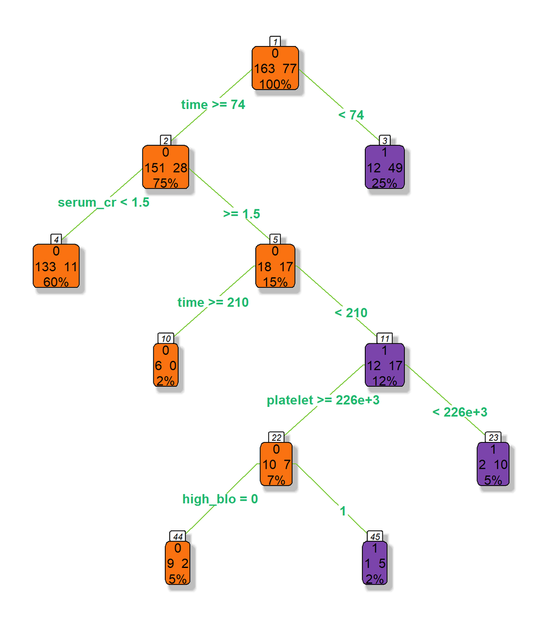

```r
pred <- as.factor(predict(cart, newdata=test)[, 2] >= 0.5) %>%
  fct_recode("0" = "FALSE", "1" = "TRUE")
confusionMatrix(pred, test$DEATH_EVENT, positive = "1")
```

```
## Confusion Matrix and Statistics
##
##           Reference
## Prediction  0  1
##          0 37  5
##          1  3 14
##
##                Accuracy : 0.8644
##                  95% CI : (0.7502, 0.9396)
##     No Information Rate : 0.678
##     P-Value [Acc > NIR] : 0.0009098
##
##                   Kappa : 0.6806
##
##  Mcnemar's Test P-Value : 0.7236736
##
##             Sensitivity : 0.7368
##             Specificity : 0.9250
##          Pos Pred Value : 0.8235
##          Neg Pred Value : 0.8810
##              Prevalence : 0.3220
##          Detection Rate : 0.2373
##    Detection Prevalence : 0.2881
##       Balanced Accuracy : 0.8309
##
##        'Positive' Class : 1
##
```

Bu karar ağacına baktığımızda dallanma kararında “trombositler” ve “yüksek kan basıncı” gibi yüksek p değerlerine sahip özelliklerin kullanıldığını görürüz. Açıklayıcı değişkenleri yalnızca istatistiksel olarak anlamlı olanlara daraltalım ve karar ağacını yeniden oluşturalım.

## Budanmış karar ağacı

```r
set.seed(0)
cart <- rpart(DEATH_EVENT ~ age + ejection_fraction + serum_creatinine + serum_sodium + time,
              data = train, method = "class",
              control=rpart.control(minsplit=20,
                                    minbucket=10,
                                    maxdepth=10,
                                    cp=0.03))
```

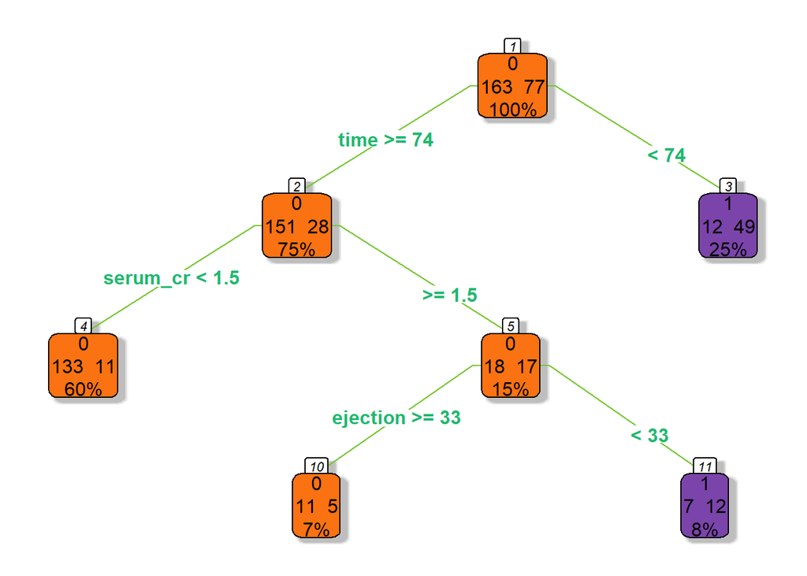

```r
pred <- as.factor(predict(cart, newdata=test)[, 2] >= 0.5) %>%
  fct_recode("0" = "FALSE", "1" = "TRUE")
confusionMatrix(pred, test$DEATH_EVENT, positive = "1")
```

```
## Confusion Matrix and Statistics
##
##           Reference
## Prediction  0  1
##          0 38  3
##          1  2 16
##
##                Accuracy : 0.9153
##                  95% CI : (0.8132, 0.9719)
##     No Information Rate : 0.678
##     P-Value [Acc > NIR] : 1.629e-05
##
##                   Kappa : 0.8032
##
##  Mcnemar's Test P-Value : 1
##
##             Sensitivity : 0.8421
##             Specificity : 0.9500
##          Pos Pred Value : 0.8889
##          Neg Pred Value : 0.9268
##              Prevalence : 0.3220
##          Detection Rate : 0.2712
##    Detection Prevalence : 0.3051
##       Balanced Accuracy : 0.8961
##
##        'Positive' Class : 1
##
```

```r
acc_cart <- confusionMatrix(pred, test$DEATH_EVENT)$overall["Accuracy"]
tpr_cart <- confusionMatrix(pred, test$DEATH_EVENT)$byClass["Specificity"]
```

Böylesine basit bir modelle, doğruluğu %91,53’e ve geri çağırmayı %84,21’e çıkarabildik. Bununla birlikte, şekil, takip süresi (“süresi”) 74 günden az olan tüm hastaların ölü olarak kabul edildiğini göstermektedir ki bu pratik açıdan kullanımı zor görünmektedir. Referans için, burada açıklayıcı değişken olarak “zaman” içermeyen bir karar ağacı var.

```r
set.seed(0)
cart <- rpart(DEATH_EVENT ~ age + ejection_fraction + serum_creatinine + serum_sodium,
              data = train, method = "class",
              control=rpart.control(minsplit=10,
                                    minbucket=5,
                                    maxdepth=10,
                                    cp=0.01))
```

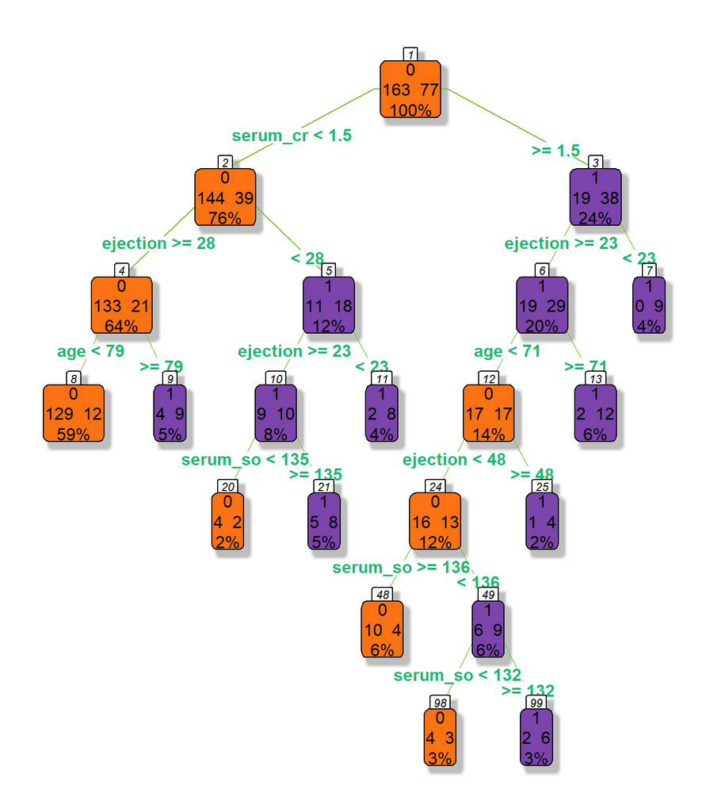

```r
pred <- as.factor(predict(cart, newdata=test)[, 2] >= 0.5) %>%
  fct_recode("0" = "FALSE", "1" = "TRUE")
confusionMatrix(pred, test$DEATH_EVENT, positive = "1")
```

```
## Confusion Matrix and Statistics
##
##           Reference
## Prediction  0  1
##          0 33  7
##          1  7 12
##
##                Accuracy : 0.7627
##                  95% CI : (0.6341, 0.8638)
##     No Information Rate : 0.678
##     P-Value [Acc > NIR] : 0.1029
##
##                   Kappa : 0.4566
##
##  Mcnemar's Test P-Value : 1.0000
##
##             Sensitivity : 0.6316
##             Specificity : 0.8250
##          Pos Pred Value : 0.6316
##          Neg Pred Value : 0.8250
##              Prevalence : 0.3220
##          Detection Rate : 0.2034
##    Detection Prevalence : 0.3220
##       Balanced Accuracy : 0.7283
##
##        'Positive' Class : 1
##
```

Model biraz karmaşık olsa da %76,27 doğrulukla model oluşturmayı başardık.

## Random forest

Random forest, test verilerini örnekleyen ve çıkaran, her örnek için paralel olarak karar ağaçları oluşturan ve bu karar ağaçlarının ortalamasına veya çoğunluğuna göre tahminlerde bulunan bir modeldir. Daha önce olduğu gibi, modeli eğitip tahminlerde bulunacağız.

```r
set.seed(0)
rf <- ranger(DEATH_EVENT ~.,
             data = train,
             mtry = 2, num.trees = 500, write.forest=TRUE, importance = "permutation")
```

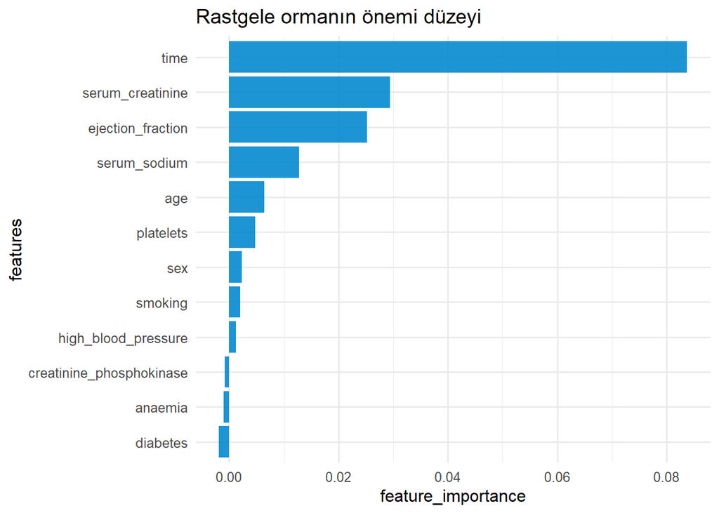

```r
pred <- predict(rf, data=test)$predictions
confusionMatrix(pred, test$DEATH_EVENT, positive = "1")
```

```
## Confusion Matrix and Statistics
##
##           Reference
## Prediction  0  1
##          0 38  3
##          1  2 16
##
##                Accuracy : 0.9153
##                  95% CI : (0.8132, 0.9719)
##     No Information Rate : 0.678
##     P-Value [Acc > NIR] : 1.629e-05
##
##                   Kappa : 0.8032
##
##  Mcnemar's Test P-Value : 1
##
##             Sensitivity : 0.8421
##             Specificity : 0.9500
##          Pos Pred Value : 0.8889
##          Neg Pred Value : 0.9268
##              Prevalence : 0.3220
##          Detection Rate : 0.2712
##    Detection Prevalence : 0.3051
##       Balanced Accuracy : 0.8961
##
##        'Positive' Class : 1
##
```

```r
acc_rf <- confusionMatrix(pred, test$DEATH_EVENT)$overall["Accuracy"]
tpr_rf <- confusionMatrix(pred, test$DEATH_EVENT)$byClass["Specificity"]
```

Bu şekilde, yüksek doğruluk ve yüksek geri çağırma elde etmeyi başardık. Referans olarak, karar ağacındaki ile aynı yüksek derecede önemli açıklayıcı değişkenleri kullanarak, ancak “time” olmadan bir model oluşturacağız.

```r
set.seed(0)
rf <- ranger(DEATH_EVENT ~ age + ejection_fraction + serum_creatinine,
             data = train,
             mtry = 3, num.trees = 100, write.forest=TRUE, importance = "permutation")
```

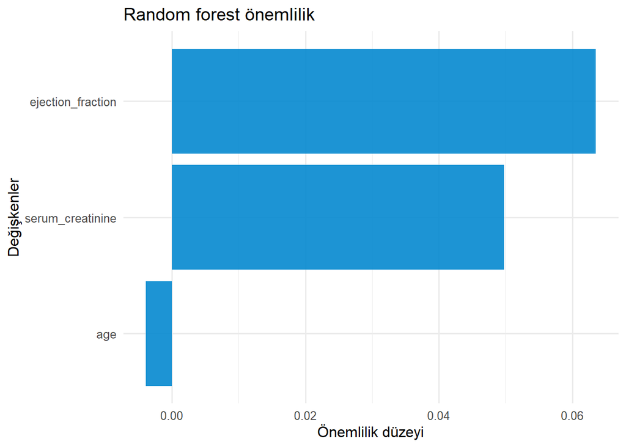

```r
pred <- predict(rf, data=test)$predictions
confusionMatrix(pred, test$DEATH_EVENT, positive = "1")
```

```
## Confusion Matrix and Statistics
##
##           Reference
## Prediction  0  1
##          0 36  6
##          1  4 13
##
##                Accuracy : 0.8305
##                  95% CI : (0.7103, 0.9156)
##     No Information Rate : 0.678
##     P-Value [Acc > NIR] : 0.006651
##
##                   Kappa : 0.6008
##
##  Mcnemar's Test P-Value : 0.751830
##
##             Sensitivity : 0.6842
##             Specificity : 0.9000
##          Pos Pred Value : 0.7647
##          Neg Pred Value : 0.8571
##              Prevalence : 0.3220
##          Detection Rate : 0.2203
##    Detection Prevalence : 0.2881
##       Balanced Accuracy : 0.7921
##
##        'Positive' Class : 1
##
```

Karar ağacından daha iyi tahmin doğruluğuna sahip bir model oluşturmayı başardık.

# Soru 2

Veri kaynağı : https://www.kaggle.com/tolgahancepel/toyota-corolla/notebooks?datasetId=286921&language=R

**Verim Hakkinda bilgi:**

| Değişken | Açıklama |
| --- | --- |
| Age | Yıl cinsinden yaş |
| KM | Kilometre |
| FuelType | Yakıt tipi (Petrol, Diesel, CNG) |
| HP | Beygir Gücü |
| MetColor | Metalik Renkli Mi? (Yes=1, No=0) |
| Automatic | Otomatik mi? ( (Yes=1, No=0) |
| CC | Santimetre küp cinsinden Silindir Hacmi |
| Doors | Kapı sayısı |
| Weight | Ağırlık |
| Price | Fiyatı |

*Bağımlı değişkenimiz “Price” dir.*

```
##      Price            Age              KM           FuelType          HP
##  Min.   : 4350   Min.   : 1.00   Min.   :     1   CNG   :  17   Min.   : 69.0
##  1st Qu.: 8450   1st Qu.:44.00   1st Qu.: 43000   Diesel: 155   1st Qu.: 90.0
##  Median : 9900   Median :61.00   Median : 63390   Petrol:1264   Median :110.0
##  Mean   :10731   Mean   :55.95   Mean   : 68533                 Mean   :101.5
##  3rd Qu.:11950   3rd Qu.:70.00   3rd Qu.: 87021                 3rd Qu.:110.0
##  Max.   :32500   Max.   :80.00   Max.   :243000                 Max.   :192.0
##  MetColor Automatic       CC       Doors       Weight
##  0:467    0:1356    Min.   :1300   2:  2   Min.   :1000
##  1:969    1:  80    1st Qu.:1400   3:622   1st Qu.:1040
##                     Median :1600   4:138   Median :1070
##                     Mean   :1567   5:674   Mean   :1072
##                     3rd Qu.:1600           3rd Qu.:1085
##                     Max.   :2000           Max.   :1615
```

```
##     Price       Age        KM  FuelType        HP  MetColor Automatic        CC
##         0         0         0         0         0         0         0         0
##     Doors    Weight
##         0         0
```

Eksik gözlem yoktur, gerekli dönüşümler yapıldı.

## Regression Tree

Şimdi modeli kuralım;

```r
set.seed(100)
train1 = sample(1:nrow(Toyota),150)
tree.Toyota=tree(Price~., Toyota, subset=train1)
summary(tree.Toyota)
```

```
##
## Regression tree:
## tree(formula = Price ~ ., data = Toyota, subset = train1)
## Variables actually used in tree construction:
## [1] "Age" "HP"  "KM"
## Number of terminal nodes:  7
## Residual mean deviance:  1203000 = 1.72e+08 / 143
## Distribution of residuals:
##     Min.  1st Qu.   Median     Mean  3rd Qu.     Max.
## -3948.00  -607.20    27.67     0.00   577.70  3680.00
```

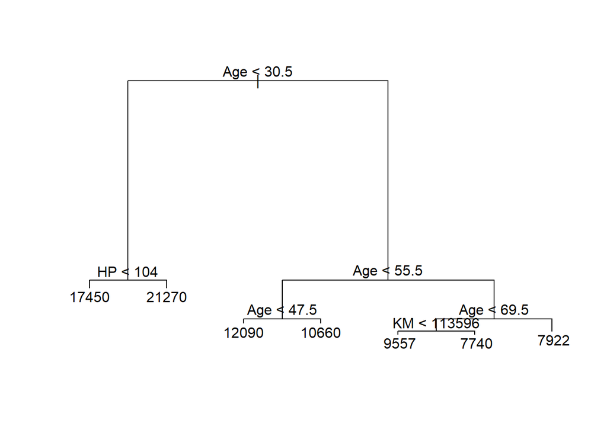

```r
plot(tree.Toyota)
text(tree.Toyota, pretty = 0)
```

Budamamız gerekip gerekmediğine karar verelim.

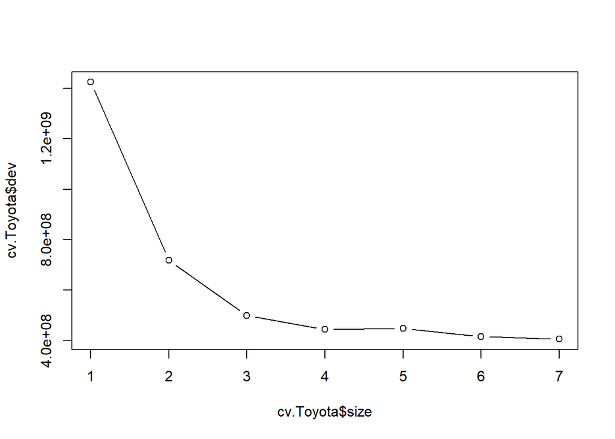

```r
cv.Toyota=cv.tree(tree.Toyota,method="deviance")
plot(cv.Toyota$size,cv.Toyota$dev,type='b')
```

Cross validation sonucu gördük ki bu ağaçta budama yapmamıza gerek yok.

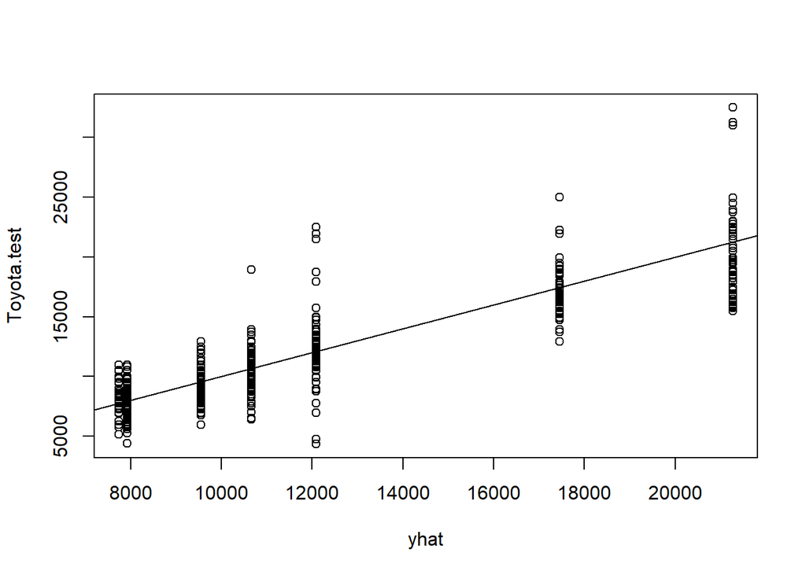

```r
yhat=predict(tree.Toyota,newdata=Toyota[-train1,])
Toyota.test=Toyota[-train1,"Price"]
plot(yhat,Toyota.test)
abline(0,1)
```

Bu saçılım grafiğinden anlaşılacağı gibi 7 node herbirindeki gözlemler için ortak bir yanıt vardır.

```r
mean((yhat-Toyota.test)^2)
```

```
## [1] 2910798
```

MSE değeri 2910798 bulunmuştur.

## Bagging and Random Forrests

```r
set.seed(0)
bag.Toyota = randomForest(Price~.,data=Toyota,subset=train1,mtry=13,importance=TRUE)
bag.Toyota
```

```
##
## Call:
##  randomForest(formula = Price ~ ., data = Toyota, mtry = 13, importance = TRUE,      subset = train1)
##                Type of random forest: regression
##                      Number of trees: 500
## No. of variables tried at each split: 9
##
##           Mean of squared residuals: 1895777
##                     % Var explained: 79.55
```

Kurulan modelin Mean of squared residuals: 1895777 dir.

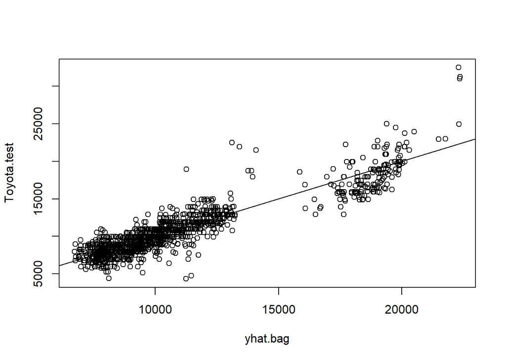

```r
yhat.bag = predict(bag.Toyota,newdata=Toyota[-train1,])
plot(yhat.bag, Toyota.test)
abline(0,1)
```

```r
mean((yhat.bag-Toyota.test)^2)
```

```
## [1] 2158975
```

Grafikten genel olarak değerler çizginin üstündedir. MSE si 2158975 bulunmuştur. Toplam varyansın 79.55 sini açıklamaktadır.

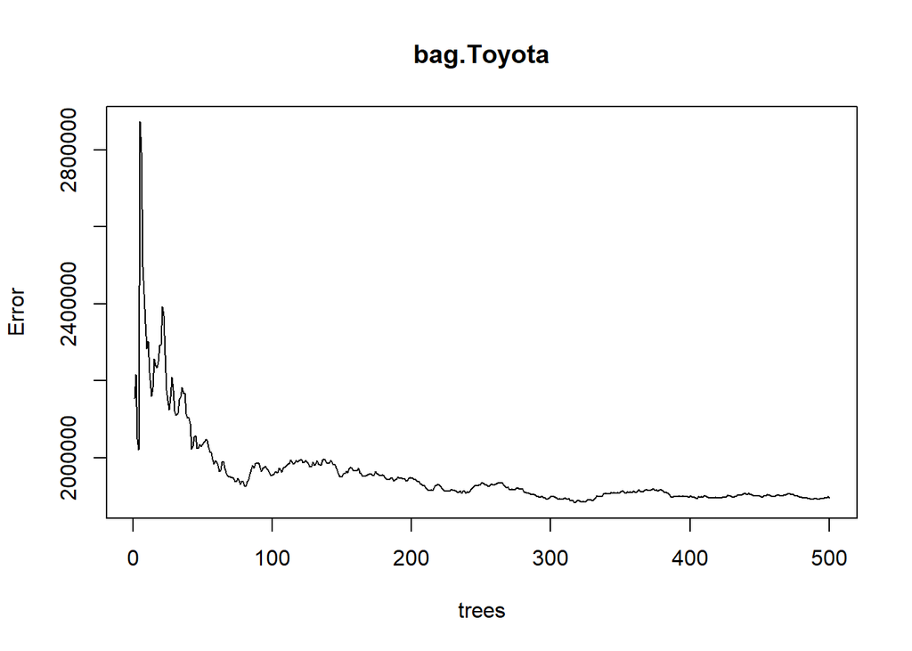

```r
plot(bag.Toyota)
```

Default olarak 500 demiştik fakat görüldüğü gibi 100 bootstrap sample bile yeterlidir. MSE değeri 100 den sonra çokda büyük değişiklikler göstermemiştir.

```r
head(bag.Toyota$mse,100)
```

```
##   [1] 2154289 2215338 2048692 2020696 2872440 2793761 2496172 2425053 2347755
##  [10] 2283559 2303070 2220463 2159894 2182892 2256873 2238872 2232684 2249756
##  [19] 2291885 2293278 2392832 2368953 2267268 2176113 2149332 2124169 2157886
##  [28] 2208902 2175487 2121058 2110544 2115110 2151401 2158223 2181589 2167140
##  [37] 2167801 2114418 2102677 2103676 2089046 2021369 2028684 2053525 2056853
##  [46] 2023511 2024702 2033633 2029113 2033900 2040664 2047374 2045042 2026784
##  [55] 2015415 2013027 1996296 1984176 1992946 1988046 1979453 1963576 1968059
##  [64] 1988330 1990341 1973625 1959758 1952534 1950615 1950361 1948858 1946416
##  [73] 1937411 1936731 1946744 1940342 1930142 1939401 1937335 1926804 1925698
##  [82] 1937479 1943479 1957549 1969669 1979958 1972129 1984664 1984983 1986946
##  [91] 1975261 1963171 1973356 1974488 1977616 1971258 1967385 1960398 1953004
## [100] 1954313
```

```r
bag.Toyota=randomForest(Price~.,data=Toyota,subset=train1,mtry=13,ntree=100)
yhat.bag = predict(bag.Toyota,newdata=Toyota[-train1,])

mean((yhat.bag-Toyota.test)^2)
```

```
## [1] 2142732
```

```r
set.seed(0)
rf.Toyota=randomForest(Price~.,data=Toyota,subset=train1,mtry=4,importance=TRUE)
yhat.rf = predict(rf.Toyota,newdata=Toyota[-train1,])
mean((yhat.rf-Toyota.test)^2)
```

```
## [1] 2015354
```

2015354 MSE değeri düşmüştür. Şimdi farklı mtray değerleri için outof bag mse değerleri ile test verisi mse değerlerini karşılaştıralım.

```r
oob.err<-double(13)
test.err<-double(13)

for(mtry in 1:13)
{
  rf=randomForest(Price ~ . , data = Toyota , subset = train1,mtry=mtry,ntree=500)
  oob.err[mtry] = rf$mse[500]

  pred<-predict(rf,Toyota[-train1,])
  test.err[mtry]= with(Toyota[-train1,], mean( (Price - pred)^2))

  cat(mtry," ")
}
```

```
## 1  2  3  4  5  6  7  8  9
```

```
## 10
```

```
## 11
```

```
## 12
```

```
## 13
```

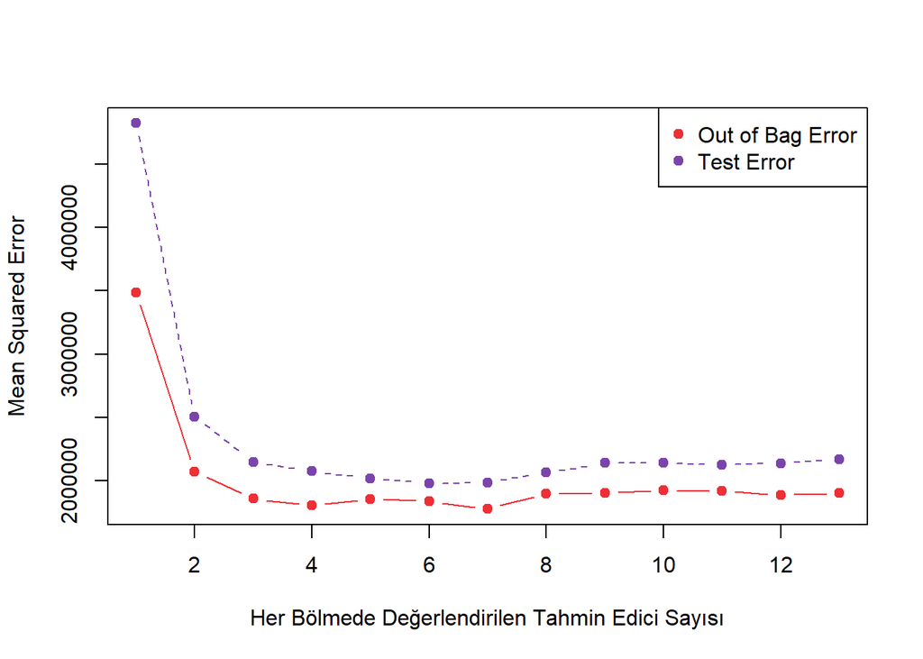

```r
matplot(1:mtry , cbind(oob.err,test.err), pch=19 , col=c("#ee2f35", "#7b44ab"),type="b",ylab="Mean Squared Error",
        xlab="Her Bölmede Değerlendirilen Tahmin Edici Sayısı")
legend("topright",legend=c("Out of Bag Error","Test Error"),pch=19, col=c("#ee2f35", "#7b44ab"))
```

```r
test.err[4]
```

```
## [1] 2076111
```

MSE 2076111 olarak bulduk.

## Boosting

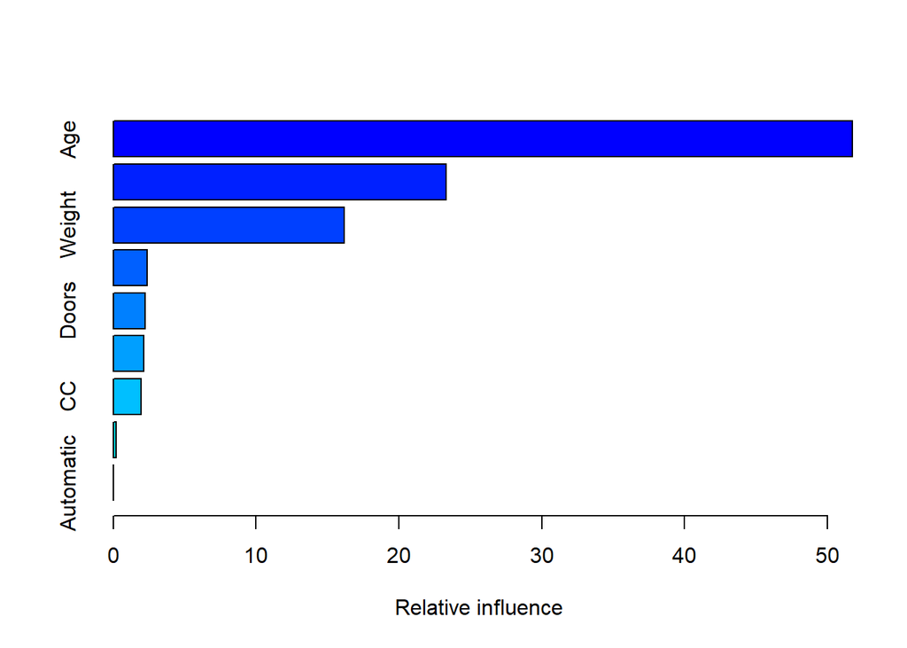

```
##                 var    rel.inf
## Age             Age 51.7471577
## KM               KM 23.2822133
## Weight       Weight 16.1462334
## HP               HP  2.3471711
## Doors         Doors  2.2036372
## MetColor   MetColor  2.1496179
## CC               CC  1.9246268
## FuelType   FuelType  0.1993425
## Automatic Automatic  0.0000000
```

```r
set.seed(0)
boost.Toyota=gbm(Price~.,data=Toyota[train1,],distribution="gaussian",n.trees=5000,interaction.depth=4)
summary(boost.Toyota)
```

En yüksek değeri age değişkeni almış. Modeli test edersek;

```r
yhat.boost=predict(boost.Toyota,newdata=Toyota[-train1,],n.trees=5000)
mean((yhat.boost-Toyota.test)^2)
```

```
## [1] 2863910
```

MSE = 2863910

# Soru 3

Veri Kaynağı: https://github.com/SteffiPeTaffy/machineLearningAZ/tree/master/Machine%20Learning%20A-Z%20Template%20Folder/Part%204%20-%20Clustering/Section%2024%20-%20K-Means%20Clustering

| Değişken | Açıklama |
| --- | --- |
| CustomerID | Müşteriye atanan benzersiz kimlik |
| Gender | Müşterinin cinsiyeti |
| Age | Müşterinin yaşı |
| AnnualIncome | Yıllık Geliri |
| SpendingScore | Alışveriş merkezi tarafından müşteri davranışına ve harcama niteliğine göre belirlenen puan |

```r
head(mall_customers)
```

```
##   CustomerID Gender Age AnnualIncome SpendingScore
## 1          1   Male  19           15            39
## 2          2   Male  21           15            81
## 3          3 Female  20           16             6
## 4          4 Female  23           16            77
## 5          5 Female  31           17            40
## 6          6 Female  22           17            76
```

```r
sum(is.na(mall_customers))
```

```
## [1] 0
```

Eksik gözlem yok.

**Veriyi Modellemeye Hazırlama**

```r
# müşteri verileri başına
mall_customers_cont <- mall_customers[,c(1,3:5)]

mall_customers_cont <- mall_customers_cont %>%
  distinct(CustomerID,.keep_all = TRUE)

head(mall_customers_cont)
```

```
##   CustomerID Age AnnualIncome SpendingScore
## 1          1  19           15            39
## 2          2  21           15            81
## 3          3  20           16             6
## 4          4  23           16            77
## 5          5  31           17            40
## 6          6  22           17            76
```

```r
# rank
mall_customers_cont <- mall_customers_cont %>%
  mutate(Age = rank(Age),AnnualIncome = rank(AnnualIncome),
         SpendingScore=rank(SpendingScore))

head(mall_customers_cont)
```

```
##   CustomerID  Age AnnualIncome SpendingScore
## 1          1  8.5          1.5          58.5
## 2          2 20.0          1.5         171.5
## 3          3 15.0          3.5          10.5
## 4          4 28.5          3.5         166.0
## 5          5 66.5          5.5          61.5
## 6          6 24.0          5.5         163.5
```

```r
# standartlaştırma
mall_customers_norm <- mall_customers_cont %>%
mutate_at(c(2:4),funs(c(scale(.))))
head(mall_customers_norm)
```

```
##   CustomerID        Age AnnualIncome SpendingScore
## 1          1 -1.5901519    -1.711078    -0.7257755
## 2          2 -1.3913829    -1.711078     1.2269062
## 3          3 -1.4778042    -1.676511    -1.5552332
## 4          4 -1.2444667    -1.676511     1.1318642
## 5          5 -0.5876648    -1.641944    -0.6739344
## 6          6 -1.3222459    -1.641944     1.0886633
```

```r
summary(mall_customers_norm)
```

```
##    CustomerID          Age            AnnualIncome      SpendingScore
##  Min.   :  1.00   Min.   :-1.69386   Min.   :-1.71108   Min.   :-1.71076
##  1st Qu.: 50.75   1st Qu.:-0.84045   1st Qu.:-0.85986   1st Qu.:-0.83378
##  Median :100.50   Median : 0.01728   Median : 0.01728   Median : 0.00864
##  Mean   :100.50   Mean   : 0.00000   Mean   : 0.00000   Mean   : 0.00000
##  3rd Qu.:150.25   3rd Qu.: 0.89014   3rd Qu.: 0.93332   3rd Qu.: 0.89858
##  Max.   :200.00   Max.   : 1.71114   Max.   : 1.71108   Max.   : 1.71940
```

```r
sapply(mall_customers_norm[,-1],sd)
```

```
##           Age  AnnualIncome SpendingScore
##             1             1             1
```

Rank ve standartlaşma uygulayıp veriyi uygun forma getirdik.

```r
final_data <- column_to_rownames(mall_customers_norm, var = "CustomerID")
head(final_data)
```

```
##          Age AnnualIncome SpendingScore
## 1 -1.5901519    -1.711078    -0.7257755
## 2 -1.3913829    -1.711078     1.2269062
## 3 -1.4778042    -1.676511    -1.5552332
## 4 -1.2444667    -1.676511     1.1318642
## 5 -0.5876648    -1.641944    -0.6739344
## 6 -1.3222459    -1.641944     1.0886633
```

## K-Means Clustring

```r
k_4 <- final_data
```

```r
set.seed(1)
cluster_4 <- kmeans(k_4, 4)
```

```r
# final_data'ya küme etiketleri eklersek
k_4$cluster <- cluster_4$cluster
head(k_4)
```

```
##          Age AnnualIncome SpendingScore cluster
## 1 -1.5901519    -1.711078    -0.7257755       2
## 2 -1.3913829    -1.711078     1.2269062       2
## 3 -1.4778042    -1.676511    -1.5552332       2
## 4 -1.2444667    -1.676511     1.1318642       2
## 5 -0.5876648    -1.641944    -0.6739344       2
## 6 -1.3222459    -1.641944     1.0886633       2
```

```r
print(cluster_4$cluster)
```

```
##   1   2   3   4   5   6   7   8   9  10  11  12  13  14  15  16  17  18  19  20
##   2   2   2   2   2   2   1   2   1   2   1   2   1   2   1   2   1   2   1   2
##  21  22  23  24  25  26  27  28  29  30  31  32  33  34  35  36  37  38  39  40
##   1   2   1   2   1   2   1   2   1   2   1   2   1   2   1   2   1   2   1   2
##  41  42  43  44  45  46  47  48  49  50  51  52  53  54  55  56  57  58  59  60
##   1   2   1   2   1   2   1   2   2   2   1   2   2   1   1   1   1   1   2   1
##  61  62  63  64  65  66  67  68  69  70  71  72  73  74  75  76  77  78  79  80
##   1   2   1   1   1   2   1   1   2   2   1   1   1   1   1   2   1   1   2   1
##  81  82  83  84  85  86  87  88  89  90  91  92  93  94  95  96  97  98  99 100
##   1   1   1   1   2   1   1   2   2   1   1   2   1   1   2   2   1   2   1   2
## 101 102 103 104 105 106 107 108 109 110 111 112 113 114 115 116 117 118 119 120
##   2   1   1   2   1   2   1   1   1   1   1   2   3   2   2   2   1   1   1   1
## 121 122 123 124 125 126 127 128 129 130 131 132 133 134 135 136 137 138 139 140
##   2   3   4   4   3   4   3   4   3   4   3   4   3   4   3   4   3   4   3   4
## 141 142 143 144 145 146 147 148 149 150 151 152 153 154 155 156 157 158 159 160
##   3   4   3   4   3   4   3   4   3   4   3   4   3   4   3   4   3   4   3   4
## 161 162 163 164 165 166 167 168 169 170 171 172 173 174 175 176 177 178 179 180
##   3   4   3   4   3   4   3   4   3   4   3   4   3   4   3   4   3   4   3   4
## 181 182 183 184 185 186 187 188 189 190 191 192 193 194 195 196 197 198 199 200
##   3   4   3   4   3   4   3   4   3   4   3   4   3   4   3   4   3   4   3   4
```

```r
#Kümeleme için yalnızca Gelir ve puan sütun ekleme
new.mall = mall_customers %>%
  select(AnnualIncome, SpendingScore)

names(new.mall)
```

```
## [1] "AnnualIncome"  "SpendingScore"
```

## Hierarchical kümeleme

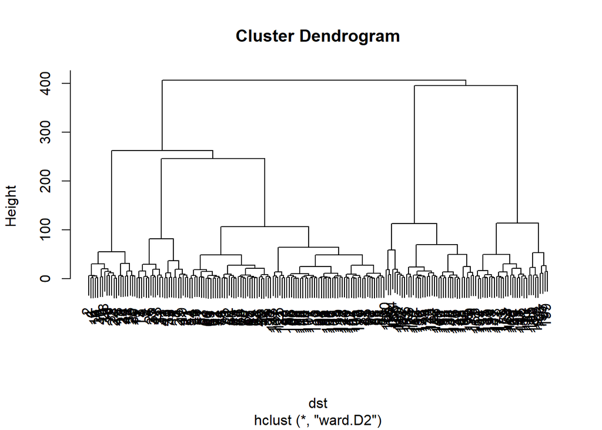

```r
# Dst'ye Hiyerarşik işlevi çalıştırma
hc = hclust(dst, method = "ward.D2")
plot(hc)
```

```r
#Hc'den kümeyi içe aktaralım ve ana veri kümesine atayalım
mall_customers$cluster = as.factor(cutree(hc, k = 5))
```

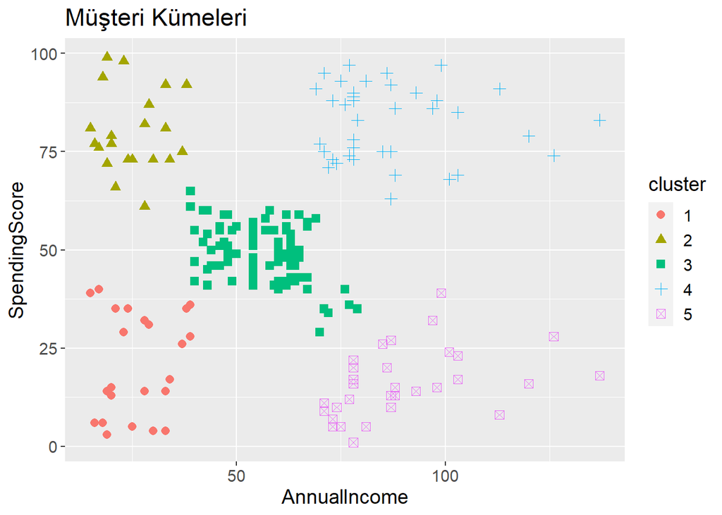

```r
#Harcama puanlarına ve Yıllık gelire göre kümelerin dağılımı için puan çizelgesi
p = ggplot(mall_customers, aes(AnnualIncome,SpendingScore, shape = cluster, color = cluster))
p +   geom_point(size = 2.5) +labs(title = 'Müşteri Kümeleri') + theme(text = element_text(size = 14))
```